# PALMER PENGUINS

Pauline MASSERON

02/11/2020

## Introduction

Ce jeu de données contient des mesures de taille, de poids ou encore le sexe pour trois espèces de manchots observées sur trois îles de l’archipel Palmer, en Antarctique.

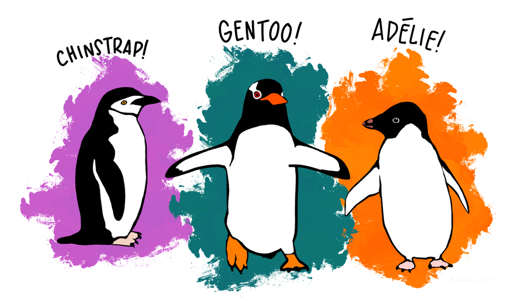

Les manchots de l’archipel Palmer. Illustration de @allison_horst .

Ces données ont été recueillies de 2007 à 2009 par le Dr Kristen Gorman avec le programme de recherche écologique à long terme de la station Palmer, qui fait partie du réseau américain de recherche écologique à long terme .

```r
#Quelques statistiques descriptives

summary(penguins)
```

```
##    species             island          bill_length_mm  bill_depth_mm
##  Length:344         Length:344         Min.   :32.10   Min.   :13.10
##  Class :character   Class :character   1st Qu.:39.23   1st Qu.:15.60
##  Mode  :character   Mode  :character   Median :44.45   Median :17.30
##                                        Mean   :43.92   Mean   :17.15
##                                        3rd Qu.:48.50   3rd Qu.:18.70
##                                        Max.   :59.60   Max.   :21.50
##                                        NA's   :2       NA's   :2
##  flipper_length_mm  body_mass_g       sex                 year
##  Min.   :172.0     Min.   :2700   Length:344         Min.   :2007
##  1st Qu.:190.0     1st Qu.:3550   Class :character   1st Qu.:2007
##  Median :197.0     Median :4050   Mode  :character   Median :2008
##  Mean   :200.9     Mean   :4202                      Mean   :2008
##  3rd Qu.:213.0     3rd Qu.:4750                      3rd Qu.:2009
##  Max.   :231.0     Max.   :6300                      Max.   :2009
##  NA's   :2         NA's   :2
```

Cette base de données contient 344 observations. Regardons la répartition du nombre de manchot par espèce :

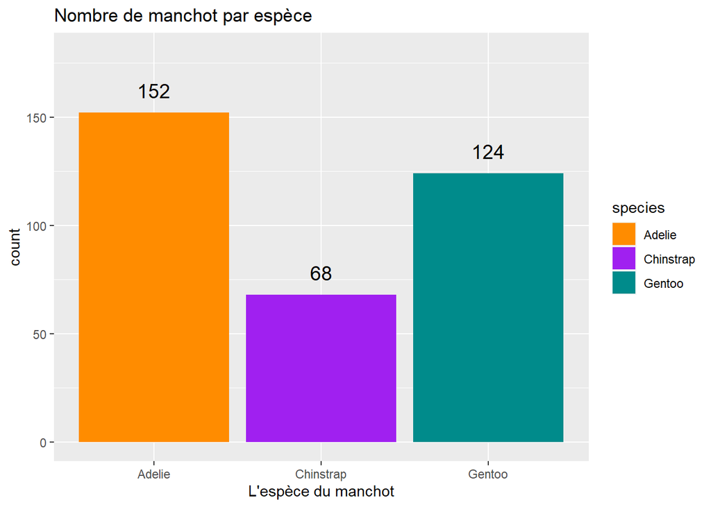

```r
penguins %>%
  ggplot(aes(x = species, fill = species)) +
  geom_bar() +
  geom_text(stat = "count", aes(label = (..count..)), vjust = -1, size = 5) +
  coord_cartesian(ylim = c(0,180))+
  scale_fill_manual(values = c("darkorange","purple","cyan4")) +
  labs(x = "L'espèce du manchot", title = "Nombre de manchot par espèce")
```

Regardons également le nombre de mâles et de femelles par espèce de manchot :

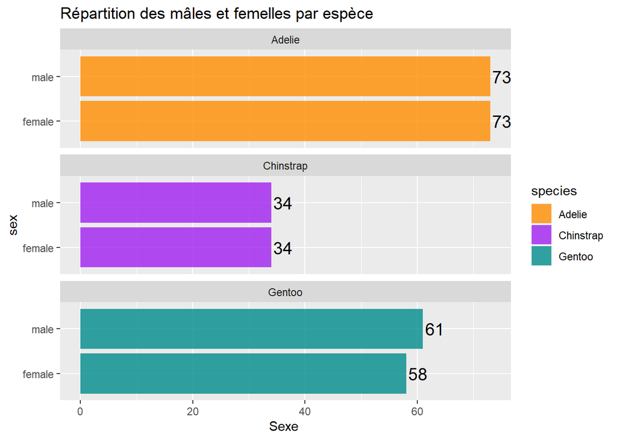

```r
penguins %>%
  filter(sex != "N/A") %>%
  ggplot(aes(x = sex, fill = species)) +
  geom_bar(alpha = 0.8) +
  geom_text(stat = "count", aes(label = (..count..)), hjust = -0.1, size = 5) +
  scale_fill_manual(values = c("darkorange","purple","cyan4")) +
  facet_wrap (~species, ncol  =  1 ) +
  coord_flip() +
  labs(y = "Sexe ", title = "Répartition des mâles et femelles par espèce")
```

## Présentation de la base de données

On peut, tout d’abord, explorer les distribution.

Analysons la longueur du bec par espèce :

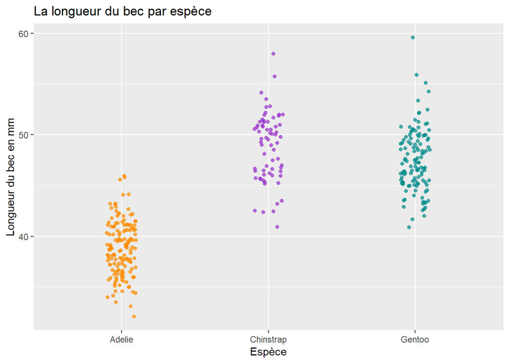

```r
penguins %>%
  ggplot(aes(x = species, y = bill_length_mm)) +
  geom_jitter(aes(col = species), width = 0.1, alpha = 0.7, show.legend = FALSE) +
  scale_color_manual(values = c("darkorange","darkorchid","cyan4")) +
  labs(x = "Espèce", y = "Longueur du bec en mm", title = "La longueur du bec par espèce")
```

Ou encore la longueur des nageoires par espèce :

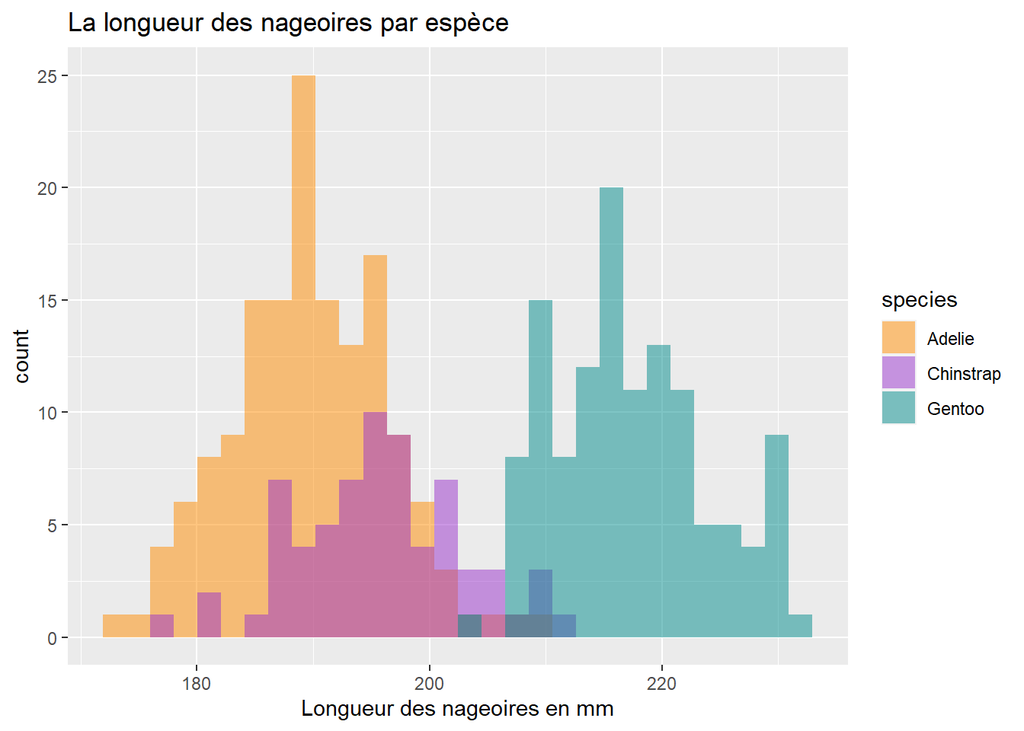

```r
penguins %>%
  ggplot(aes(x = flipper_length_mm))+
  geom_histogram(aes(fill = species), alpha = 0.5, position = "identity") +
  scale_fill_manual(values = c("darkorange","darkorchid","cyan4")) +
  labs(x = "Longueur des nageoires en mm", title = "La longueur des nageoires par espèce")
```

De plus, ces données ont quatre variables continues, ce qui rend possible de représenter des nuages de point.

La longueur de la nageoire du manchot et la masse corporelle montrent une association positive pour chacune des 3 espèces :

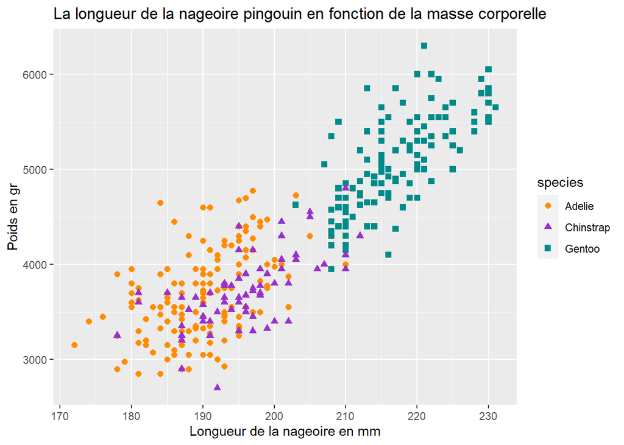

```r
penguins %>%
  ggplot(aes(x = flipper_length_mm, y = body_mass_g)) +
  geom_point(aes(color = species, shape = species), size = 2) +
  scale_color_manual(values = c("darkorange","darkorchid","cyan4")) +
  labs(x = "Longueur de la nageoire en mm", y = "Poids en gr", title = "La longueur de la nageoire pingouin en fonction de la masse corporelle")
```

On peut ajouter la distinction du genre :

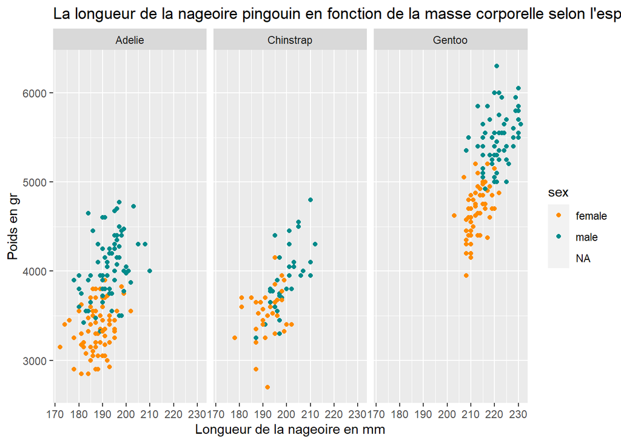

```r
penguins %>%
  ggplot(aes(x = flipper_length_mm , y = body_mass_g)) +
  geom_point(aes(color = sex)) +
  scale_color_manual (values = c("darkorange" ,"cyan4")) +
  facet_wrap (~ species) +
  labs(x = "Longueur de la nageoire en mm", y = "Poids en gr", title = "La longueur de la nageoire pingouin en fonction de la masse corporelle selon l'espèce et le sexe")
```

La longueur et la profondeur du bec de manchot montrent également des modèles intéressants.

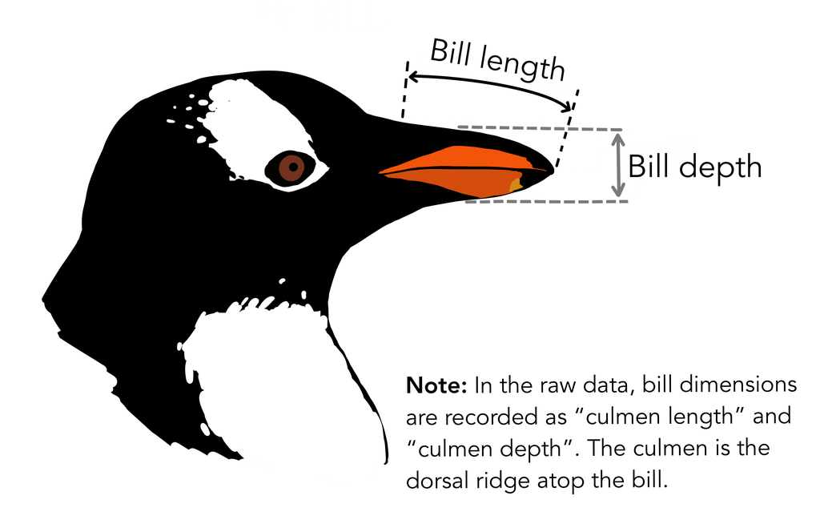

Si on ignore les espèces, on pourrait penser qu’il y a une corrélation négative entre ces deux variables :

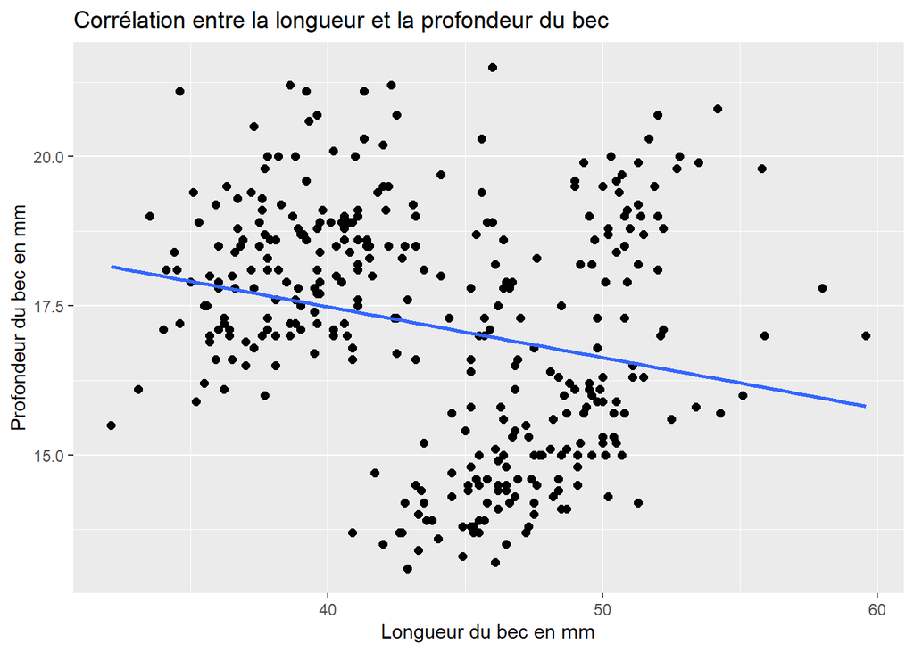

```r
penguins %>%
  ggplot(aes(x = bill_length_mm, y = bill_depth_mm)) +
  geom_point(size = 2) +
  geom_smooth(method = "lm", se = FALSE) +
  labs(x = "Longueur du bec en mm", y = "Profondeur du bec en mm", title = "Corrélation entre la longueur et la profondeur du bec")
```

Cependant, si on regarde les corrélations au sein des espèces, la longueur et la profondeur du bec sont en fait corrélées positivement :

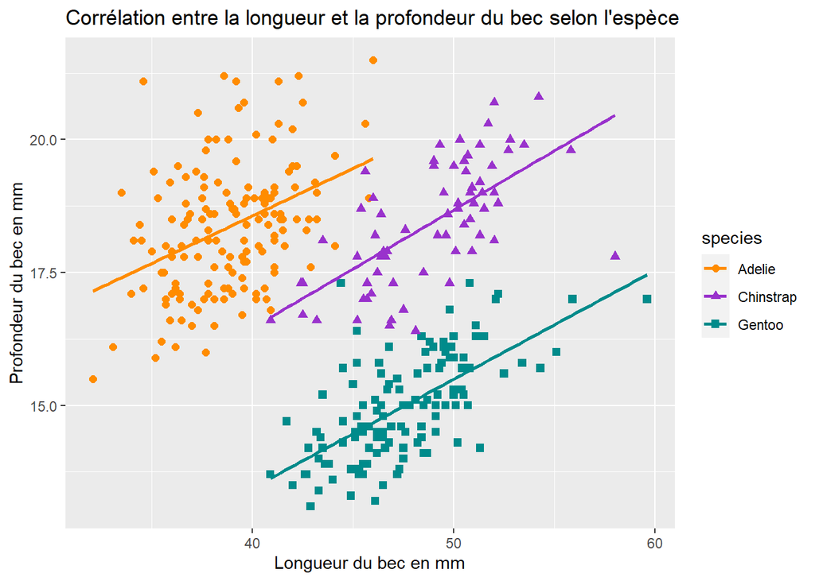

```r
penguins %>%
  ggplot(aes(x = bill_length_mm, y = bill_depth_mm)) +
  geom_point(aes(color = species, shape = species), size = 2) +
  geom_smooth(method = "lm", se = FALSE, aes(color = species)) +
  scale_color_manual(values = c("darkorange","darkorchid","cyan4")) +
  labs(x = "Longueur du bec en mm", y = "Profondeur du bec en mm", title = "Corrélation entre la longueur et la profondeur du bec selon l'espèce")
```

Enfin, on peut obtenir une séparation assez claire entre les trois espèces en regardant la longueur des nageoires par rapport à la longueur du bec:

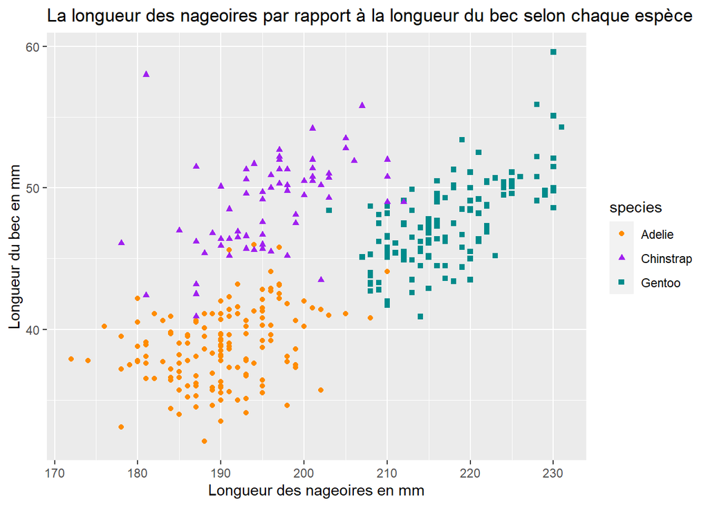

```r
penguins %>%
  ggplot(aes(x = flipper_length_mm, y = bill_length_mm, colour = species, shape = species)) +
  geom_point() +
  scale_colour_manual(values = c("darkorange","purple","cyan4")) +
  labs(x = "Longueur des nageoires en mm", y = "Longueur du bec en mm", title = "La longueur des nageoires par rapport à la longueur du bec selon chaque espèce")
```

## Questions

- Les pingouins mâles sont-ils plus gros que les pingouins femelles ?

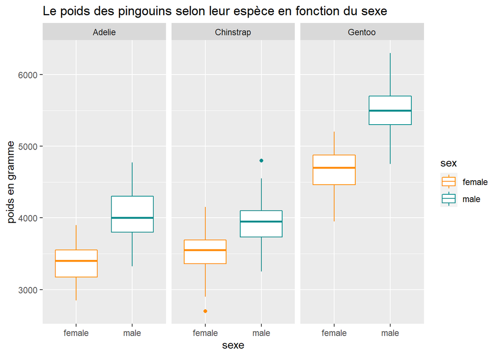

```r
penguins %>%
  filter(sex != "N/A") %>%
  ggplot(aes(x = sex, y = body_mass_g)) +
  geom_boxplot() +
  facet_wrap(~species)+
  aes(color = sex)+
  scale_color_manual (values = c("darkorange" ,"cyan4")) +
  labs(x = "sexe", y = "poids en gramme", title = "Le poids des pingouins selon leur espèce en fonction du sexe")
```

- Quelle est la répartition des trois espèces de manchot sur les différentes îles de l’archipel Palmer ?

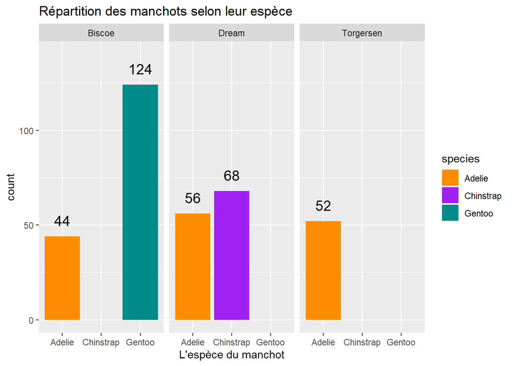

```r
penguins %>%
  ggplot(aes(x = species, fill = species)) +
  geom_bar() +
  geom_text(stat = "count", aes(label = (..count..)), vjust = -1, size = 5) +
  coord_cartesian(ylim = c(0,140))+
  facet_wrap(~island) +
  scale_fill_manual(values = c("darkorange","purple","cyan4")) +
  labs(x = "L'espèce du manchot", title = "Répartition des manchots selon leur espèce")
```

- Est-ce que l’île, sur laquelle les manchots “Adelie” sont, influe sur le poids de ces derniers ?

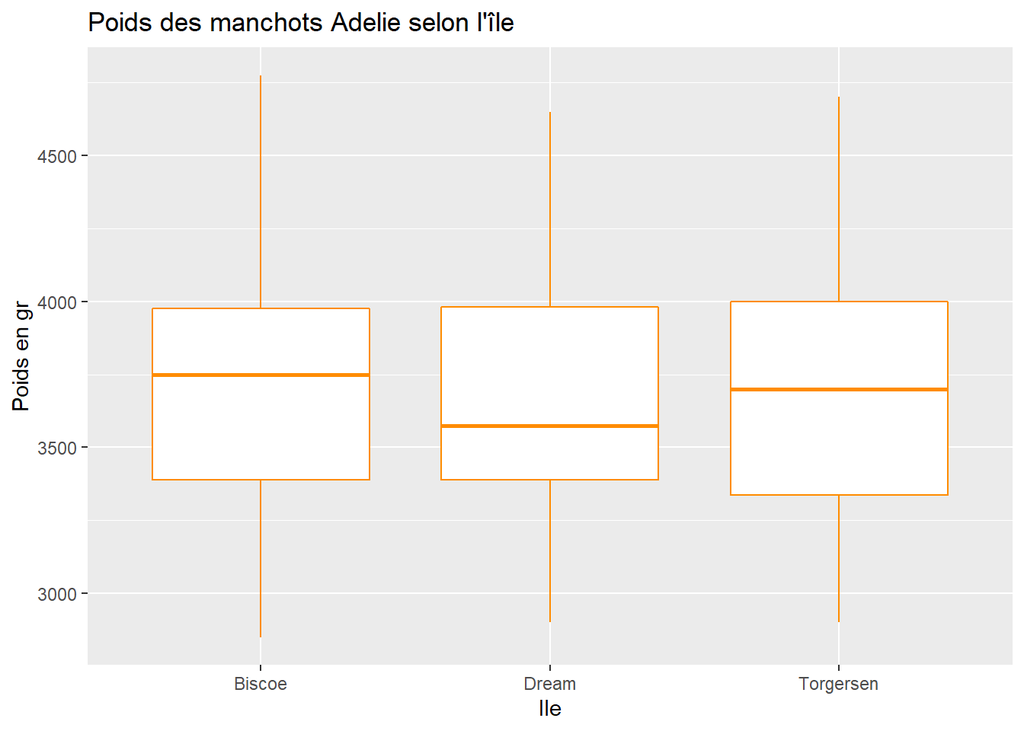

```r
penguins %>%
  filter(species == "Adelie") %>%
  ggplot(aes(x = island, y = body_mass_g))+
  geom_boxplot(col = "darkorange") +
  labs(x = "Ile", y = "Poids en gr", title = "Poids des manchots Adelie selon l'île")
```